# Modelos ARIMA

Miguel G.

7/4/2022

# Modelos ARIMA: Precio del oro

Analizaremos la serie de tiempo mensual del oro, para tratar de estimar un modelo ARIMA y generar un pronóstico para los siguientes 12 meses.

ARIMA(p,d,q): Orden p: Número de autorregresivos, rezagos de $y_t$ Orden d: Número de integración, cuantas veces debo diferenciar la serie para volverla estacionaria Orden q: Número de medias moviles, rezagos de $e_t$

```r
rm(list=ls())

setwd("C:/Users/Miike/Dropbox/pronosticos/2 Notas/arma")

library(readxl)
library(forecast)
library(tseries)
library(lmtest)
# lmtest - sirve para hacer pruebas de hipótesis los residuales y los coeficientes estimados

precios_oro <- read_excel("oro_precio.xlsx")

oro <- ts(precios_oro$`Settlement Price`, start = c(2002,4), frequency = 12)
```

## Pruebas de raiz unitaria

Grafica de la serie

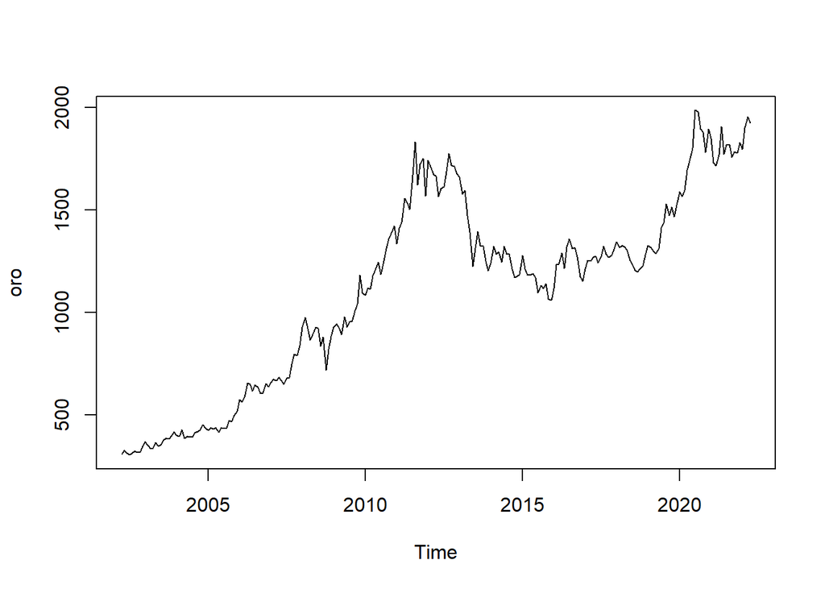

```r
ts.plot(oro)
```

```r
adf.test(oro)
```

```
##
##  Augmented Dickey-Fuller Test
##
## data:  oro
## Dickey-Fuller = -1.8324, Lag order = 6, p-value = 0.6463
## alternative hypothesis: stationary
```

No puedo rechazar la hipótesis nula, tomo las primeras diferencias y vuelvo a realizar la prueba

```r
adf.test(diff(oro))
```

```
##
##  Augmented Dickey-Fuller Test
##
## data:  diff(oro)
## Dickey-Fuller = -5.0963, Lag order = 6, p-value = 0.01
## alternative hypothesis: stationary
```

## Autocorrelación

La serie del oro es estacionaria en sus primeras diferencias, esta serie es integrada de orden 1, I(1). El siguiente paso consiste en observar la autocorrelación y autocorrelación parcial para proponer un modelo tentativo.

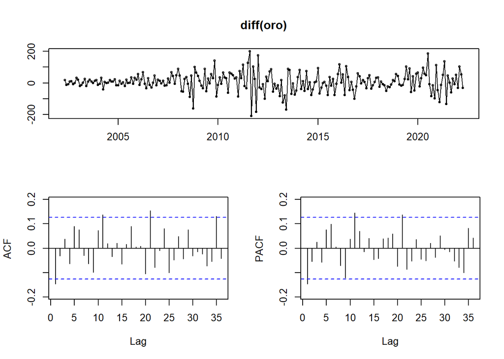

```r
tsdisplay(diff(oro))
```

Según el ACF y PACF, un modelo tentativo es un ARIMA (1,1,1) Otros modelos son: ARIMA(1,1,2), ARIMA(1,1,0), ARIMA(0,1,1), cada uno con y sin constante (drift / deriva)

## Estimar los modelos tentativos

```r
modelo_1 <- Arima(oro, order = c(1,1,1), include.constant = FALSE)
modelo_2 <- Arima(oro, order = c(1,1,1), include.constant = TRUE)

modelo_3 <- Arima(oro, order = c(1,1,2), include.constant = FALSE)
modelo_4 <- Arima(oro, order = c(1,1,2), include.constant = TRUE)

modelo_5 <- Arima(oro, order = c(1,1,0), include.constant = FALSE)
modelo_6 <- Arima(oro, order = c(1,1,0), include.constant = TRUE)

modelo_7 <- Arima(oro, order = c(0,1,1), include.constant = FALSE)
modelo_8 <- Arima(oro, order = c(0,1,1), include.constant = TRUE)
```

```r
modelo_1$bic
```

```
## [1] 2648.922
```

```r
modelo_2$bic
```

```
## [1] 2649.884
```

```r
modelo_3$bic
```

```
## [1] 2653.882
```

```r
modelo_4$bic
```

```
## [1] 2654.758
```

```r
modelo_5$bic
```

```
## [1] 2643.623
```

```r
modelo_6$bic
```

```
## [1] 2644.919
```

```r
modelo_7$bic
```

```
## [1] 2643.446
```

```r
modelo_8$bic
```

```
## [1] 2644.495
```

El mejor modelo tentativo según el criterio de información de bayes es el modelo 7, es decir, un ARIMA(0,1,1)

```r
modelo_7
```

```
## Series: oro
## ARIMA(0,1,1)
##
## Coefficients:
##           ma1
##       -0.1354
## s.e.   0.0638
##
## sigma^2 = 3411:  log likelihood = -1316.24
## AIC=2636.48   AICc=2636.54   BIC=2643.45
```

## Revisar los residuales

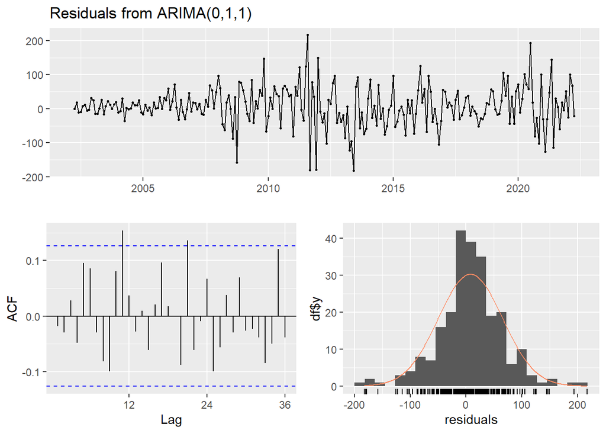

```
##
##  Ljung-Box test
##
## data:  Residuals from ARIMA(0,1,1)
## Q* = 30.544, df = 23, p-value = 0.1344
##
## Model df: 1.   Total lags used: 24
```

```r
checkresiduals(modelo_7)
```

## significancia estadística de los coeficientes estimados

```r
coeftest(modelo_7)
```

```
##
## z test of coefficients:
##
##      Estimate Std. Error z value Pr(>|z|)
## ma1 -0.135449   0.063838 -2.1218  0.03386 *
## ---
## Signif. codes:  0 '***' 0.001 '**' 0.01 '*' 0.05 '.' 0.1 ' ' 1
```

El valor p es 0.0338 Si alfa es 10%, es decir 0.10, el valor-p<alfa, se rechaza Ho al 10% de significancia Si alfa 5%, el valor-p<alfa, se rechaza Ho al 5% de significancia Si alfa 1%, el valor-p>alfa, No se rechaza Ho al 1% de significancia

El coeficiente estimado es estadísticamente significativo al 5%.

## Pronóstico

```r
pronostico_oro <- forecast(modelo_7, 12)
```

```r
pronostico_oro
```

```
##          Point Forecast    Lo 80    Hi 80    Lo 95    Hi 95
## May 2022       1926.057 1851.204 2000.910 1811.579 2040.534
## Jun 2022       1926.057 1827.108 2025.006 1774.728 2077.386
## Jul 2022       1926.057 1807.825 2044.289 1745.237 2106.877
## Aug 2022       1926.057 1791.273 2060.841 1719.923 2132.191
## Sep 2022       1926.057 1776.542 2075.571 1697.394 2154.720
## Oct 2022       1926.057 1763.138 2088.976 1676.894 2175.220
## Nov 2022       1926.057 1750.756 2101.358 1657.957 2194.157
## Dec 2022       1926.057 1739.192 2112.921 1640.272 2211.842
## Jan 2023       1926.057 1728.304 2123.810 1623.620 2228.494
## Feb 2023       1926.057 1717.984 2134.129 1607.837 2244.276
## Mar 2023       1926.057 1708.153 2143.961 1592.802 2259.312
## Apr 2023       1926.057 1698.746 2153.367 1578.415 2273.698
```

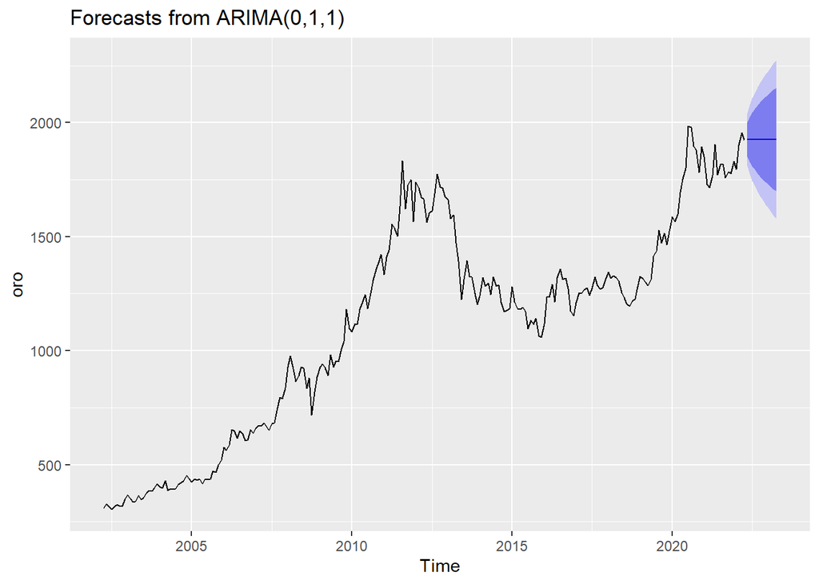

```r
autoplot(pronostico_oro)
```